# In Class Discussion

## Themes

- Loops and functions
  - This week’s problem set
- What is likelihood and what does it mean?
- Likelihood vs. *relative* likelihood vs. probability
  - https://stats.stackexchange.com/a/156937/597
- Grid approximation vs. optimization
- How Bayesian methods work “under the hood”
  - More coming soon
  - Bayes rule

\[P[\Theta | Data] = \frac{P[Data | \Theta] \times P[\Theta]}{P[Data]}\]

## Themes

- Big picture of analytical vs. ML vs. resampling vs. Bayesian
  - What do we want you to understand about them?
  - More practical examples
  - When to use each
  - Does needing to use one imply bad design?

## Mouse weaning data

```r
M <- read_excel("../data/Mouse_Weaning_Data.xlsx") %>%
  select(MouseID, Sex, WnMass) %>%
  drop_na() %>%
  mutate(Sex_f = factor(if_else(Sex == 0, "Female", "Male")))
str(M)
```

```
## Classes 'tbl_df', 'tbl' and 'data.frame':    2429 obs. of  4 variables:
##  $ MouseID: num  1 2 3 4 5 6 7 8 9 10 ...
##  $ Sex    : num  0 1 1 1 1 0 0 1 1 1 ...
##  $ WnMass : num  15.3 12.5 17.4 16.6 16.8 ...
##  $ Sex_f  : Factor w/ 2 levels "Female","Male": 1 2 2 2 2 1 1 2 2 2 ...
```

## Are the sex ratios equal?

After 3 generations

```r
M_3 <- M %>%
  filter(MouseID != -9) %>%
  filter(MouseID < 400) %>%
  mutate(Sex_f = factor(if_else(Sex == 0, "Female", "Male")))
str(M_3)
```

```
## Classes 'tbl_df', 'tbl' and 'data.frame':    191 obs. of  4 variables:
##  $ MouseID: num  1 2 3 4 5 6 7 8 9 10 ...
##  $ Sex    : num  0 1 1 1 1 0 0 1 1 1 ...
##  $ WnMass : num  15.3 12.5 17.4 16.6 16.8 ...
##  $ Sex_f  : Factor w/ 2 levels "Female","Male": 1 2 2 2 2 1 1 2 2 2 ...
```

## Are the sex ratios equal?

```r
M_3 %>% group_by(Sex_f) %>% tally()
```

```
## # A tibble: 2 x 2
##   Sex_f      n
##   <fct>  <int>
## 1 Female    91
## 2 Male     100
```

## Model Likelihood (\(\mathcal{L}\))

For a set of observations (\(Y_i\)) and hypothesized parameters (\(\Theta\)) the model likelihood is the product of the observations’ individual likelihoods:

\[\mathcal{L}\left(\left\{ Y_{i}\right\} _{i=1}^{n};\Theta\right) = \prod_{i=1}^{n}\phi\left(Y_{i}; \Theta\right)\]

Evaluate the likelihood function for different values of \(\Theta\) to estimate \(\mathcal{L}\) for different sets of \(\Theta\).

## Model Likelihood (\(\mathcal{L}\))

\[\mathcal{L}\left(\left\{ Y_{i}\right\} _{i=1}^{n};\Theta\right) = \prod_{i=1}^{n}\phi\left(Y_{i}; \Theta\right)\]

\[\log\left(\mathcal{L}\left(\left\{ Y_{i}\right\} _{i=1}^{n};\Theta\right)\right) = \sum_{i=1}^{n} \log\left(\phi\left(Y_{i};\Theta\right)\right)\]

So we just need to sum the log-likelihoods of the observations to get the model likelihood.

## Likelihood across the range of 0 to 1

Generate a range of possible values for \(\theta\):

```r
theta <- seq(0.001, 0.999, length = 200)
```

Calculate the probability for 91 female mice from 191 total mice for each value of \(\theta\):

```r
pr <- dbinom(91, 191, prob = theta)
```

Convert to log-likelihoods:

```r
log_lik <- log(pr)
log_liks <- tibble(theta, log_lik)
```

```r
log_liks
```

```
## # A tibble: 200 x 2
##      theta log_lik
##      <dbl>   <dbl>
##  1 0.001     -499.
##  2 0.00602   -337.
##  3 0.0110    -282.
##  4 0.0160    -248.
##  5 0.0211    -224.
##  6 0.0261    -205.
##  7 0.0311    -190.
##  8 0.0361    -177.
##  9 0.0411    -165.
## 10 0.0461    -155.
## # … with 190 more rows
```

## Likelihood across the range of 0 to 1

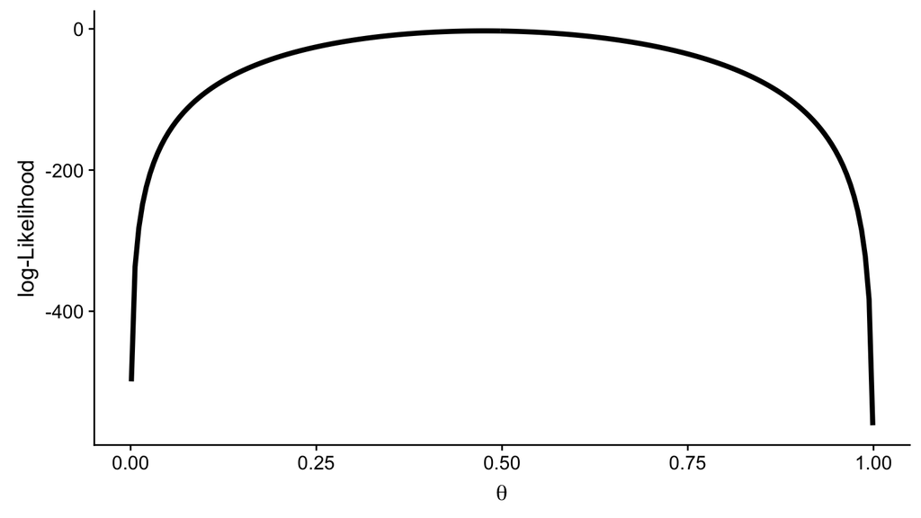

## Maximum likelihood

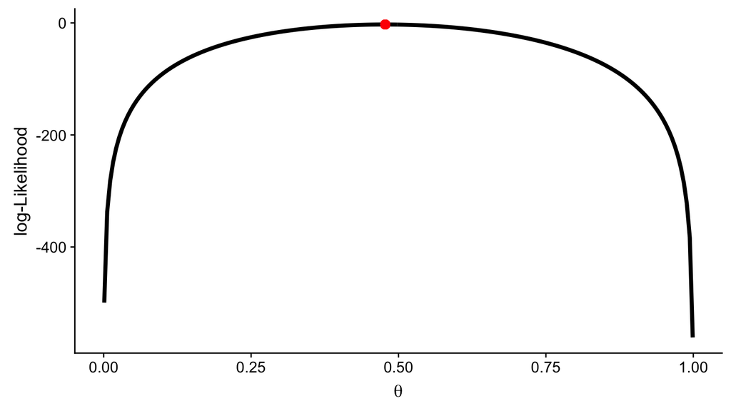

## Maximum likelihood

```r
max(log_lik)
```

```
## [1] -2.852506
```

```r
theta[which.max(log_lik)]
```

```
## [1] 0.4774322
```

```r
91 / 191
```

```
## [1] 0.4764398
```

## Probability of 91 or fewer female mice

Assuming \(\theta = 0.5\)

```r
sum(dbinom(0:91, 191, 0.5))
```

```
## [1] 0.2813992
```

## Pr[Female] for all mice

```r
M %>% group_by(Sex_f) %>% tally()
```

```
## # A tibble: 2 x 2
##   Sex_f      n
##   <fct>  <int>
## 1 Female  1202
## 2 Male    1227
```

```r
pr <- dbinom(1202, 1202 + 1227, prob = theta)
```

Convert to log-likelihoods:

```r
log_lik <- log(pr)
log_liks <- tibble(theta, log_lik)
```

```r
log_liks
```

```
## # A tibble: 200 x 2
##      theta log_lik
##      <dbl>   <dbl>
##  1 0.001      -Inf
##  2 0.00602    -Inf
##  3 0.0110     -Inf
##  4 0.0160     -Inf
##  5 0.0211     -Inf
##  6 0.0261     -Inf
##  7 0.0311     -Inf
##  8 0.0361     -Inf
##  9 0.0411     -Inf
## 10 0.0461     -Inf
## # … with 190 more rows
```

## Likelihood across the range of 0 to 1

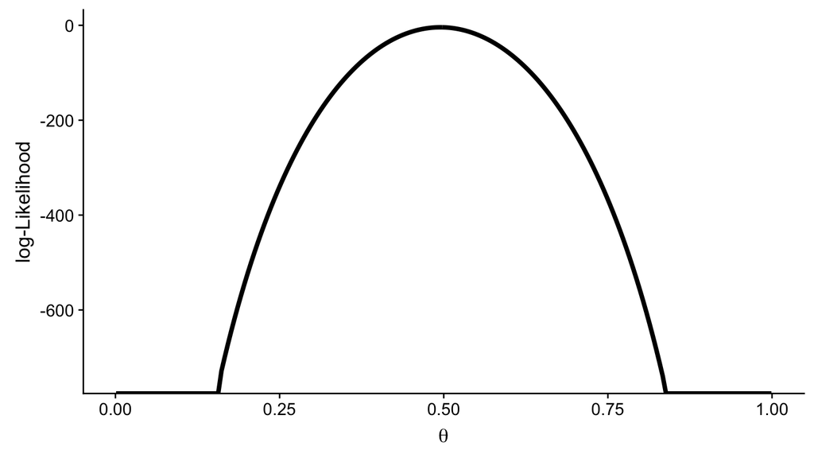

## Maximum likelihood

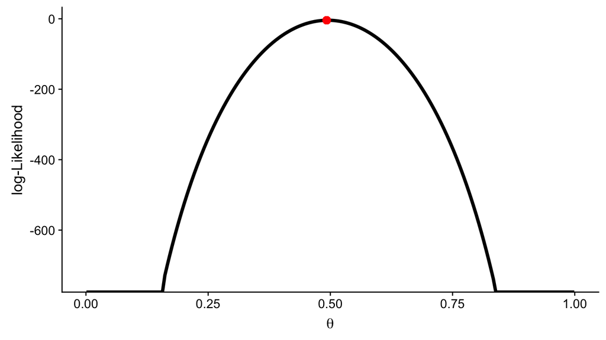

## Maximum likelihood

```r
max(log_lik)
```

```
## [1] -4.1509
```

```r
theta[which.max(log_lik)]
```

```
## [1] 0.4924774
```

```r
1202 / (1202 + 1227)
```

```
## [1] 0.4948538
```

## Mouse weaning data

```r
M <- read_excel("../data/Mouse_Weaning_Data.xlsx") %>%
  select(MouseID, Sex, WnMass) %>%
  drop_na() %>%
  mutate(Sex_f = factor(if_else(Sex == 0, "Female", "Male")))
str(M)
```

```
## Classes 'tbl_df', 'tbl' and 'data.frame':    2429 obs. of  4 variables:
##  $ MouseID: num  1 2 3 4 5 6 7 8 9 10 ...
##  $ Sex    : num  0 1 1 1 1 0 0 1 1 1 ...
##  $ WnMass : num  15.3 12.5 17.4 16.6 16.8 ...
##  $ Sex_f  : Factor w/ 2 levels "Female","Male": 1 2 2 2 2 1 1 2 2 2 ...
```

## Mouse weaning data

```r
M %>%
  ggplot(aes(WnMass, color = Sex_f)) +
  geom_line(stat = "density", size = 1.5) +
  facet_grid(Sex_f ~ .) +
  scale_color_manual(values = c("Orange", "Purple"), name = "Sex") +
  labs(x = "Wean Mass (g)", y = "Density", title = "Weaning Mass")
```

## Mouse weaning data

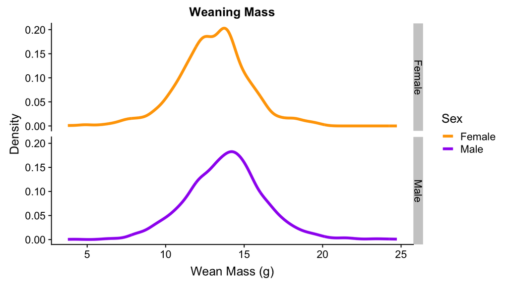

## What is the weaning mass of male mice?

Analytical mean:

```r
Males <- M %>% filter(Sex_f == "Male")
Males %>%
  summarize(mean_mass = mean(WnMass))
```

```
## # A tibble: 1 x 1
##   mean_mass
##       <dbl>
## 1      13.8
```

## Likelihood for each observed value

\[\phi\left(Y_i; \mu, \sigma\right) = \frac{1}{\sqrt{2\pi\sigma^{2}}} e^{\frac{-\left(Y_i-\mu\right)^{2}}{2\sigma^{2}}}\]

- For any \(\mu\) and \(\sigma\) we can calculate the likelihood of *that* observation
- Some values of \(\mu\) and \(\sigma\) will maximize the likelhood for *that* observation

What values of \(\mu\) and \(\sigma\) *simultaneously* maximize the likelihood for *all* the observations?

## Model Likelihood (\(\mathcal{L}\))

For a set of observations (\(Y_i\)) and hypothesized parameters (\(\Theta\), here \(\mu\) and \(\sigma\)) the model likelihood is the product of the observations’ individual likelihoods:

\[\mathcal{L}\left(\left\{ Y_{i}\right\} _{i=1}^{n};\Theta\right) = \prod_{i=1}^{n}\phi\left(Y_{i}; \Theta\right)\]

\[\log\left(\mathcal{L}\left(\left\{ Y_{i}\right\} _{i=1}^{n};\Theta\right)\right) = \sum_{i=1}^{n} \log\left(\phi\left(Y_{i};\Theta\right)\right)\]

## General ML procedure

Search the parameter space of \(\Theta\) (here \(\mu\) and \(\sigma\)) for the values that maxmimize the likelihood. For each possible \(\mu\) and \(\sigma\):

1. Calculate the likelihood for each *observation*
2. Sum the log-likelihoods
3. Search until log-likelihood is maximized

The analytical mean *equals* the ML estimate of the mean.

- Why not just use the analytical solution in all cases?

## Searching the parameter space

1. Grid approximation
   - Slow, coarse, doesn’t scale well
2. Optimization
   - Harder to set up
   - General solution

## Likelihood function

```r
log_lik <- function(x, Y){
  liks <- dnorm(Y, mean = x[1], sd = x[2])
  return(sum(log(liks)))
}
```

- Pass a vector of `x <- c(mu, sigma)` and vector of `Y` values
- Calculate the likelihoods (probability densities) for each `Y` given the mean and standard deviation
- Return the sum of the logs of the likelihoods

## Grid approximation

For combinations of \(\mu\) and \(\sigma\), calculate the model likelihood. Pick the largest log-likelihood as the maximum likelihood estimates.

Set up the grid:

```r
n <- 100 # How fine is the grid
mu <- seq(5, 20, length = n) # Vector of mu
sigma <- seq(0.1, 5, length = n) # Vector of sigma

grid_approx <- crossing(mu, sigma) %>%
  mutate(log_lik = NA)
```

```r
grid_approx
```

```
## # A tibble: 10,000 x 3
##       mu sigma log_lik
##    <dbl> <dbl> <lgl>
##  1     5 0.1   NA
##  2     5 0.149 NA
##  3     5 0.199 NA
##  4     5 0.248 NA
##  5     5 0.298 NA
##  6     5 0.347 NA
##  7     5 0.397 NA
##  8     5 0.446 NA
##  9     5 0.496 NA
## 10     5 0.545 NA
## # … with 9,990 more rows
```

## Grid approximation

```r
for (ii in 1:nrow(grid_approx)) {
  grid_approx[ii, "log_lik"] <-
    log_lik(c(grid_approx$mu[ii], grid_approx$sigma[ii]),
            Males$WnMass)
}
```

- Iterate through the rows (\(ii\)) of `grid_approx`
- For each row, assign the model log-likelihood calculated for that `mu` and `sigma` to `log_lik`

```r
head(grid_approx)
```

```
## # A tibble: 6 x 3
##      mu sigma log_lik
##   <dbl> <dbl>   <dbl>
## 1     5 0.1      -Inf
## 2     5 0.149    -Inf
## 3     5 0.199    -Inf
## 4     5 0.248    -Inf
## 5     5 0.298    -Inf
## 6     5 0.347    -Inf
```

This approach is coarse, time consuming, and not feasible for fine grids or many parameters.

- For a 100 X 100 grid, there are 10,000 calculations.
- If there were 3 parameters, there would be 1,000,000.

## Grid approximation

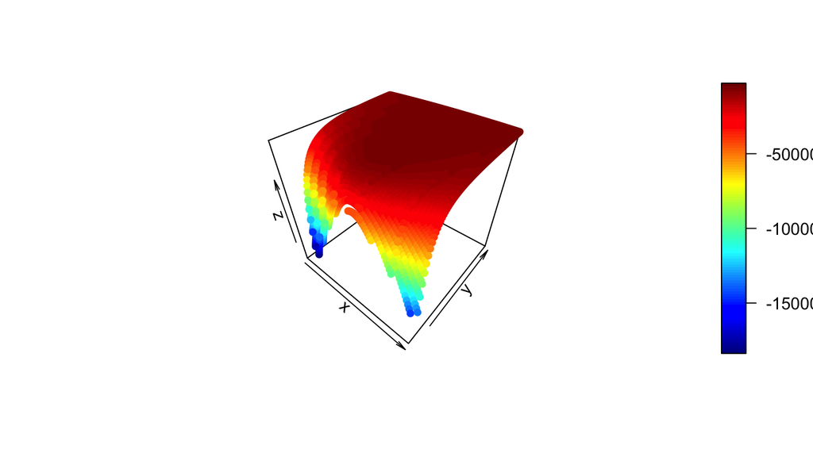

## Grid approximation

[interactive chart not shown]

## Grid approximation

On this grid, the maximum likelihood estimate of \(\mu\) is:

```r
grid_approx[which.max(grid_approx$log_lik), ]
```

```
##            mu    sigma   log_lik
## 5849 13.78788 2.475758 -2845.812
```

The analytical estimate is:

```r
mean(Males$WnMass)
```

```
## [1] 13.82238
```

## Grid approximation

[interactive chart not shown]

## Maximum likelihood via optimization

`reltol` says to stop when the improvement is \(<10^{-100}\).

- Default tolerance is \(10^{-8}\), so we will get a very precise estimate.

```r
MLE <- optim(c(13, 1), # Start at mu = 13, sigma = 1
             log_lik,
             Y = Males$WnMass,
             control = list(fnscale = -1,   # Find maximum
                            reltol = 10^-100))
```

## Maximum likelihood via optimization

```r
mean(Males$WnMass)
```

```
## [1] 13.82238
```

```r
print(MLE)
```

```
## $par
## [1] 13.822380  2.460218
##
## $value
## [1] -2845.644
##
## $counts
## function gradient
##      111       NA
##
## $convergence
## [1] 0
##
## $message
## NULL
```

## ML considerations

- `glm()` uses an optimization routine
- ML can get stuck in a local maximum (that isn’t the global maximum)
- Write your own custom likelihood function

## Resampling inference of the mean

```r
set.seed(36428)
reps <- 100000
resampled_mean <- numeric(length = reps)
for (i in 1:reps) {
  resampled_mean[i] <- mean(sample(Males$WnMass,
                                   replace = TRUE))
}
```

Each iteration:

- Resample `Males$WnMass` *with replacement*. Yields a vector equal in length to `Males$WnMass` but where each value can appear more than once.
- Calculate the mean of this resampled vector. Assign to the *i*th position in `resampled_mean`.

The mean of these means is the estimate of the population mean (via central limit theorem).

## Resampling inference of the mean

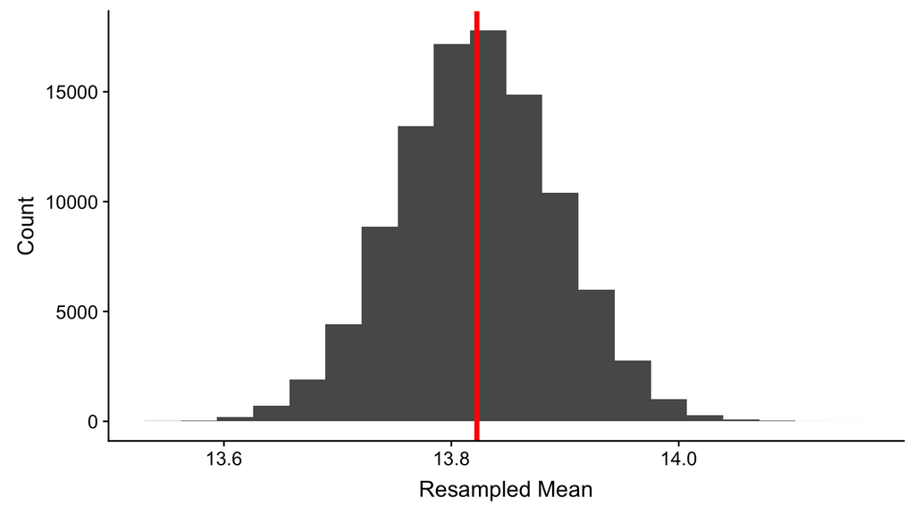

## Resampling inference of the mean

```r
mean(Males$WnMass)
```

```
## [1] 13.82238
```

```r
mean(resampled_mean)
```

```
## [1] 13.82246
```

**Given enough iterations, the resampled mean equals the analytical mean (and equals the ML mean).**

## Bayesian inference of the mean

Ranges of possible maximum likelihood values:

1. \(\mu\): \(-\infty < \mu < \infty\)
2. \(\sigma\): \(0 < \sigma < \infty\)

Drawbacks:

1. \(\mu\) can’t be negative (no negative masses) and probably isn’t very small either (biology)
2. \(\sigma\) is also probably not huge either

Can we do better? Yes, Bayesian priors.

## Prior for the mean

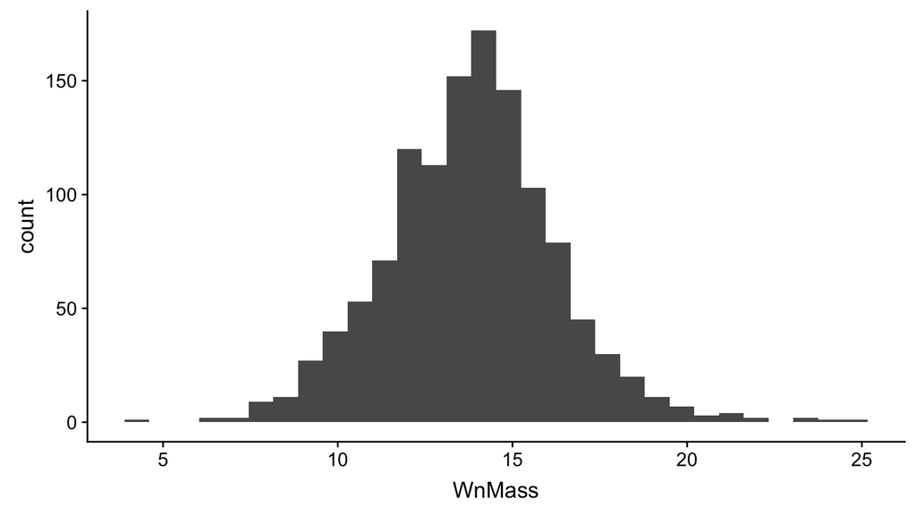

## Prior for the mean

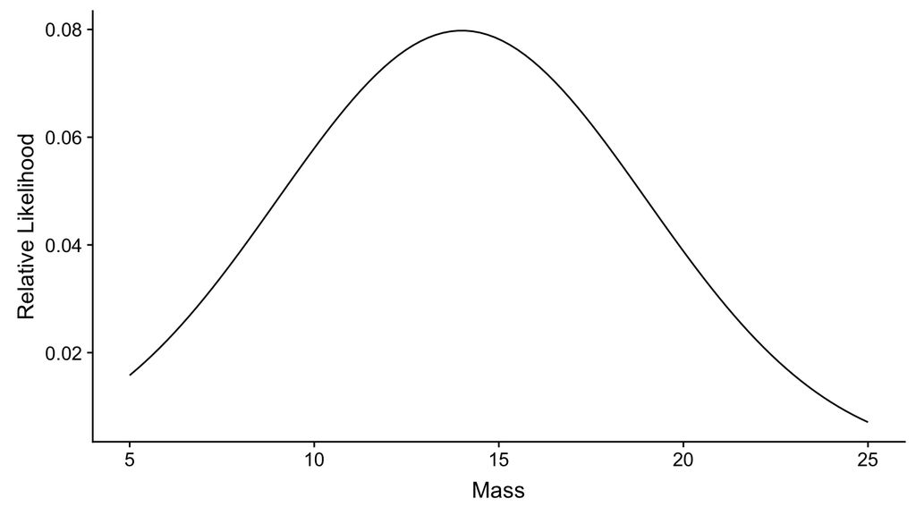

## Bayesian MCMC sampling

1. Write your own (not recommended)
2. WinBUGS / OpenBUGS
3. JAGS
4. stan

R, Python, MATLAB, etc. interfaces to samplers #2-4.

## In R

- `rstan`: Build your own models
- `rethinking`: Convenience interface to `rstan`.
- `brms` and `rstanarm`: High level model syntax

## Bayesian model for mean \(\mathcal{N}(14, 5)\)

```r
fm_sd5 <- map2stan(
  alist(
    WnMass ~ dnorm(mu, sigma),
    mu ~ dnorm(14, 5),
    sigma ~ dcauchy(0, 3)
  ),
  data = Males_sub
)
```

```
## Computing WAIC
```

```
## Constructing posterior predictions
```

[output not shown]

## Bayesian model for mean \(\mathcal{N}(14, 5)\)

```r
mean(Males_sub$WnMass)
```

```
## [1] 13.82238
```

```r
precis(fm_sd5)
```

```
##        Mean StdDev lower 0.89 upper 0.89 n_eff Rhat
## mu    13.83   0.07      13.72      13.95   865    1
## sigma  2.46   0.05       2.38       2.54   835    1
```

## Bayesian model for mean \(\mathcal{N}(14, 10)\)

```r
fm_sd10 <- map2stan(
  alist(
    WnMass ~ dnorm(mu, sigma),
    mu ~ dnorm(14, 10),
    sigma ~ dcauchy(0, 3)
  ),
  data = Males_sub
)
```

```
## Computing WAIC
```

```
## Constructing posterior predictions
```

[output not shown]

## Bayesian model for mean \(\mathcal{N}(14, 10)\)

```r
mean(Males_sub$WnMass)
```

```
## [1] 13.82238
```

```r
precis(fm_sd10)
```

```
##        Mean StdDev lower 0.89 upper 0.89 n_eff Rhat
## mu    13.83   0.07      13.72      13.94   768    1
## sigma  2.46   0.05       2.37       2.54   720    1
```

## Bayesian model for mean \(\mathcal{N}(10, 5)\)

```r
fm_mu10 <- map2stan(
  alist(
    WnMass ~ dnorm(mu, sigma),
    mu ~ dnorm(10, 5),
    sigma ~ dcauchy(0, 3)
  ),
  data = Males_sub
)
```

```
## Computing WAIC
```

```
## Constructing posterior predictions
```

[output not shown]

## Bayesian model for mean \(\mathcal{N}(10, 5)\)

```r
mean(Males_sub$WnMass)
```

```
## [1] 13.82238
```

```r
nrow(Males)
```

```
## [1] 1227
```

```r
precis(fm_mu10)
```

```
##        Mean StdDev lower 0.89 upper 0.89 n_eff Rhat
## mu    13.83   0.07      13.71      13.93  1011    1
## sigma  2.46   0.05       2.38       2.54   990    1
```

## Bayesian model for mean \(\mathcal{N}(14, 0.1)\)

```r
fm_sd0.1 <- map2stan(
  alist(
    WnMass ~ dnorm(mu, sigma),
    mu ~ dnorm(14, 0.1),
    sigma ~ dcauchy(0, 3)
  ),
  data = Males_sub
)
```

```
## Computing WAIC
```

```
## Constructing posterior predictions
```

[output not shown]

## Bayesian model for mean \(\mathcal{N}(14, 0.1)\)

```r
mean(Males_sub$WnMass)
```

```
## [1] 13.82238
```

```r
precis(fm_sd0.1)
```

```
##        Mean StdDev lower 0.89 upper 0.89 n_eff Rhat
## mu    13.88   0.06      13.79      13.97   760    1
## sigma  2.46   0.05       2.39       2.53   927    1
```

## Bayes priors

- How much information do you have?
- Try different priors
  - What is the effect?
- Explicit model comparison

## Are male mice heavier at weaning than female mice?

Wait until Week 5…